# M2.891_20241_PEC1-Solucion

# Reducción de la dimensionalidad (2.5 puntos)

En este apartado retomaremos el análisis gráfico de distribución de la clase a lo largo de las muestras del conjunto de datos. En el segundo apartado pudimos observar si las variables descriptivas por separado eran muy prometedoras o no de cara a predecir la clase. Aquí vamos a intentar determinar si su combinación puede ayudarnos a determinar si se contratará el depósito de mejor manera que utilizando los atributos por separados. Con este propósito, vamos a reducir la dimensionalidad del problema a solamente dos atributos, que serán la proyección de los atributos descriptivos originales, y observaremos de qué manera se distribuyen las muestras de cada clase.

**Ejercicio:**

- Aplicad el método de reducción de la dimensionalidad Principal Component Analysis (PCA) para reducir a 2 dimensiones el dataset entero con todas las features.
- Generad un gráfico en 2D con el resultado del PCA usando colores diferentes para cada una de las clases de la respuesta, con el objetivo de visualizar si es posible separar eficientemente las clases con este método.

NOTA: Tened cuidado, no incluyáis la variable objetivo en la reducción de dimensionalidad. Queremos explicar la variable objetivo en función del resto de variables reducidas a dos dimensiones.

Sugerencia: no es necesario que programéis el algoritmo de PCA, podéis usar la implementación disponible en la librería de *scikit-learn*.

**Solución:**

```python
pca = PCA(n_components=2, random_state=seed)
X_PCA = pca.fit_transform(X_scaled)
print("Shape of the PCA-reduced dataset:", np.shape(X_PCA))
print('Explained variance ratio (first two components): %s' % str(pca.explained_variance_ratio_))
```

```
Shape of the PCA-reduced dataset: (45211, 2)
Explained variance ratio (first two components): [0.24534493 0.18411034]
```

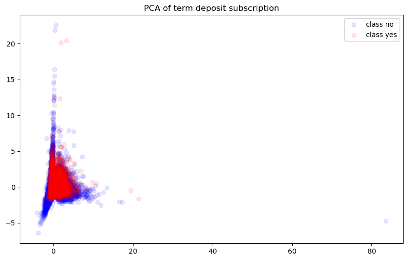

```python
colors = ['blue', 'red']
fig, axs = plt.subplots(nrows=1, ncols=1, figsize=(10,6))

for i, y_value in enumerate(y["y"].unique()):
    axs.scatter(X_PCA[y["y"] == y_value, 0], X_PCA[y["y"] == y_value, 1], color=colors[i], alpha=.1, label='class '+y_value)
axs.legend()
axs.set_title('PCA of term deposit subscription')

plt.show()
```

**Ejercicio:**

- Repetid la reducción de dimensionalidad, pero en este caso usando TSNE. Podéis encontrar más información sobre este algoritmo en el link: https://distill.pub/2016/misread-tsne/
- Al igual que antes, generad un gráfico en 2D con el resultado del PCA usando colores diferentes para cada una de las clases de la respuesta (y), con el objetivo de visualizar si es posible separar eficientemente las clases con este método.

Sugerencia: no es necesario que programéis el algoritmo TSNE, podéis usar la implementación disponible en la librería de *scikit-learn*.  
Sugerencia: a parte de especificar el número de componentes, probad a usar los parámetros "learning_rate" y "perplexity".

**Solución:**

```python
tsne = TSNE(n_components=2, random_state=seed, perplexity=20, learning_rate='auto')
X_TSNE = tsne.fit_transform(X_scaled)
print("Shape of the t-SNE-reduced dataset:", np.shape(X_TSNE))
```

```
Shape of the t-SNE-reduced dataset: (45211, 2)
```

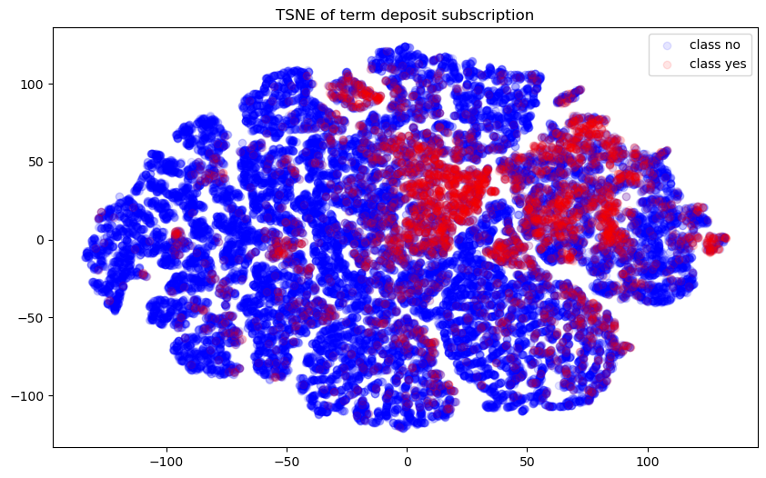

```python
colors = ['blue', 'red']
fig, axs = plt.subplots(nrows=1, ncols=1, figsize=(10,6))

for i, y_value in enumerate(y["y"].unique()):
    axs.scatter(X_TSNE[y["y"] == y_value, 0], X_TSNE[y["y"] == y_value, 1], color=colors[i], alpha=.1, label='class '+y_value)
axs.legend()
axs.set_title('TSNE of term deposit subscription')

plt.show()
```

**Análisis:** observando los dos gráficos, ¿crees que ha funcionado bien la reducción de dimensionalidad? ¿Ha conseguido separar las clases correctamente? ¿Cuál de los dos métodos ha funcionado mejor? ¿Por qué obtenemos resultados tan diferentes?

En el caso de TSNE sí que podemos intuir ciertas regiones donde abunda más una clase que otra, a diferencia del PCA, donde ambas clases se distribuyen prácticamente de la misma manera.

**Pregunta:** ¿qué opinas de TSNE como opción para reducir la dimensionalidad? ¿Qué te parece que sólo tenga el método "fit_transform" pero no tenga "transform"? ¿Conoces alguna otra opción que, con unas prestaciones similares, evite los problemas que tiene TSNE?

**Solución:** el comportamiento de TSNE varía mucho en función de sus hiperparámetros y esto puede dificultar la búsqueda de la combinación óptima de ellos. El otro gran problema viene de que sólo se pueda hacer "fit_transform", motivo por el que no podremos transformar el conjunto de datos de test que el de entrenamiento. Una buena alternativa es UMAP.

# Conjuntos desbalanceados de datos (2.5 puntos)

En los problemas de clasificación, es muy común encontrar conjuntos de datos muy desbalanceados. En la industria existen múltiples ejemplos, como la detección de fraude o la fuga de clientes. Este apartado se centra en el análisis de este tipo de conjuntos.

El caso del *dataset* con el que estamos trabajando (*Bank Marketing*) es uno de ellos, ya que podemos ver cómo la clase "no" aparece hasta un orden de magnitud más que la clase "yes".

A continuación, vamos a analizar la distribución de nuestro conjunto de datos. Para ello, utilizaremos la función **show_distribution** definida en la siguiente celda:

```python
def show_distribution(y_df):
    freq = y_df["y"].value_counts()
    plt.pie(freq, labels=('No subscription ('+str(freq["no"])+')', 'Subscription ('+str(freq["yes"])+')'), autopct='%1.1f%%')
    plt.title("Term deposit subscription distribution")
    plt.show()
```

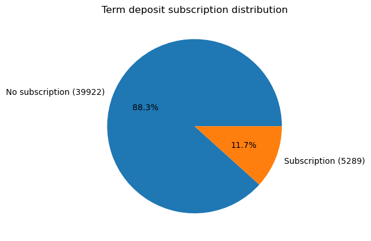

```python
show_distribution(y)
```

Cómo se puede observar, el conjunto está bastante desbalanceado, ya que, prácticamente, sólo una décima parte de las muestras se corresponden con la contratación del depósito.

Para abordar el problema de datos desbalanceados, vamos a analizar la técnica de sobremuestreo (oversampling) de la clase minoritaria. En la literatura hay más técnicas para abordar este problema, como el submuestreo (undersampling) de la clase mayoritaria, pero en esta PEC nos vamos a centrar sólo en la técnica de sobremuestreo.

## Oversampling

**Ejercicio:** incrementad las muestras de la clase minoritaria hasta alcanzar un número similar al de elementos de la clase mayoritaria, aplicando las siguientes técnicas:

- Duplicación aleatoria (random over-sampling), fijando random_state=10.
- SMOTE (Synthetic Minority Over-sampling Technique), fijando random_state=10.
- ADASYN (Adaptive Synthetic Sampling), fijando random_state=10.

Por último, comprobad, con ayuda de la función **show_distribution**, que después de la aplicación de dichas técnicas el número de muestras de la clase minoritaria se ha igualado al de la mayoritaria.

Sugerencia: para aplicar la duplicación aleatoria podéis usar "RandomOverSampler" de *imblearn*.  
Sugerencia: para aplicar smote podéis usar "SMOTE" de *imblearn*.  
Sugerencia: para aplicar adasun podéis usar "ADASYN" de *imblearn*.

**Solución:**

```python
dataset_df = pd.concat([pd.DataFrame({"0": X_TSNE[:, 0], "1": X_TSNE[:, 1]}), y], axis='columns')
```

```python
def random_over_sampling(df):
    ros = RandomOverSampler(random_state=10)
    X_resampled, y_resampled = ros.fit_resample(df[["0", "1"]], df["y"])
    X_resampled["y"] = y_resampled
    return X_resampled

def smote(df, k_neighbors=5):
    smote = SMOTE(random_state=10, k_neighbors=k_neighbors)
    X_resampled, y_resampled = smote.fit_resample(df[["0", "1"]], df["y"])
    X_resampled["y"] = y_resampled
    return X_resampled

def adasyn(df, n_neighbors=5):
    adasyn = ADASYN(random_state=10, n_neighbors=n_neighbors)
    X_resampled, y_resampled = adasyn.fit_resample(df[["0", "1"]], df["y"])
    X_resampled["y"] = y_resampled
    return X_resampled
```

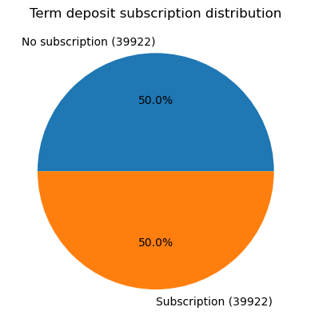

```python
ros_df = random_over_sampling(dataset_df)
smote_df = smote(dataset_df)
adasyn_df = adasyn(dataset_df)

show_distribution(ros_df)
```

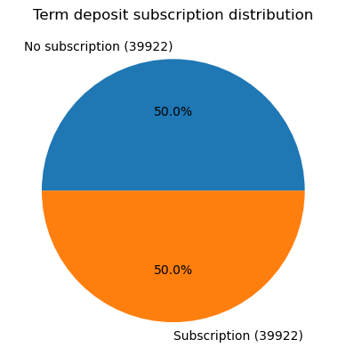

```python
show_distribution(smote_df)
```

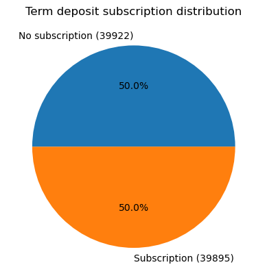

```python
show_distribution(adasyn_df)
```

El resultado de aplicar dichas técnicas nos debería de haber dado un número similar de muestras para ambas clases, sin embargo, cada uno de los métodos genera las nuevas muestras de la clase minoritaria de diferente forma. Con el objetivo de comprender mejor y de manera visual cómo se generan estas nuevas muestras utilizaremos, a partir de ahora, la descomposición a dos dimensiones que mejor se haya comportado en el apartado anterior.

**Ejercicio:** mostrad, mediante un *scatter plot* en función de las dos componentes a las que anteriormente hemos reducido el *dataset*, la distribución de las contrataciones del conjunto de datos original y el obtenido al aplicar Random Over Sampling.

**Solución:**

```python
def plot_data(dataset_df, only_subscriptions):
    colors = ['blue', 'red']
    fig, axs = plt.subplots(nrows=1, ncols=1, figsize=(10,6))

    for i, y_value in enumerate(dataset_df["y"].unique()):
        if not only_subscriptions or y_value == "yes":
            axs.scatter(dataset_df[dataset_df["y"] == y_value]["0"], dataset_df[dataset_df["y"] == y_value]["1"], color=colors[i], alpha=.1, label='class '+y_value)
    axs.legend()
    axs.set_title('TSNE of term deposit subscription')

    plt.show()
```

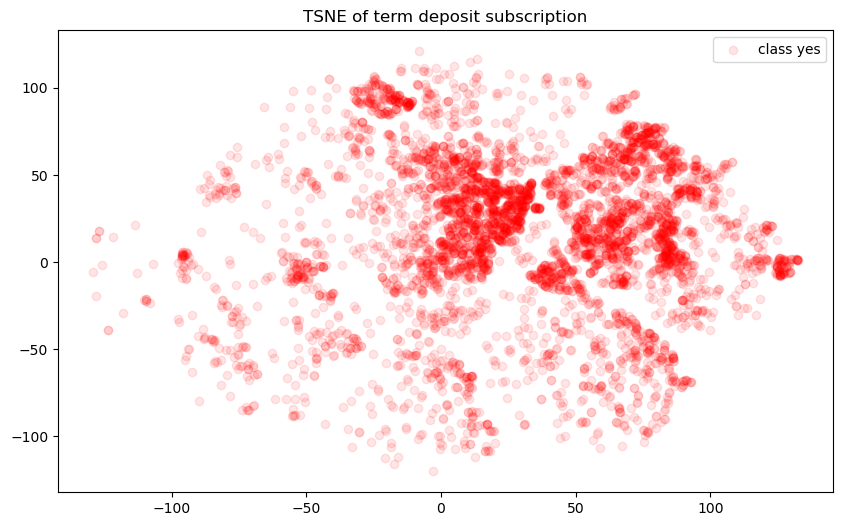

```python
plot_data(dataset_df, only_subscriptions=True)
```

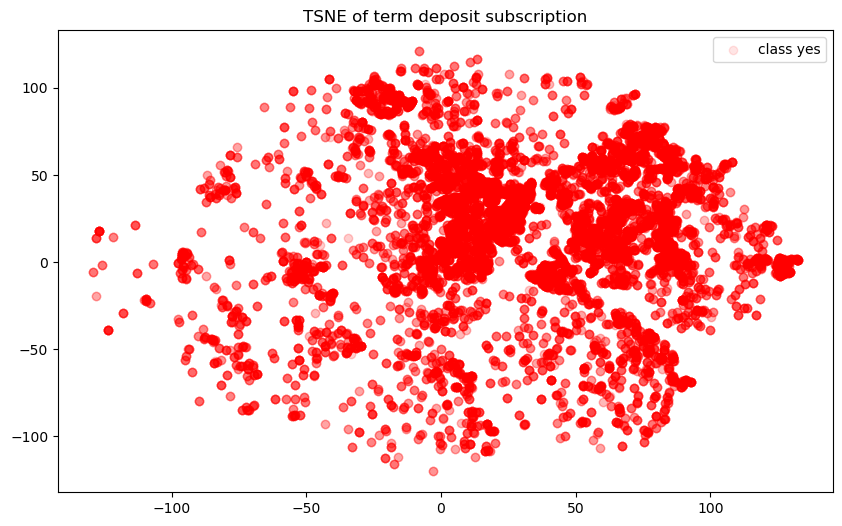

```python
plot_data(ros_df, only_subscriptions=True)
```

**Solución:** Las dos gráficas son exactamente iguales, sólo cambia el número de puntos de cada una de ellas. El resultado es el mismo porque al aplicar la técnica Random Over Sampling se han duplicado los puntos existentes de forma aleatoria hasta tener la misma proporción entre las dos clases.

**Ejercicio:** mostrad, mediante un *scatter plot* en función de las dos componentes a las que anteriormente hemos reducido el *dataset*, la distribución de las contrataciones de los tres conjuntos de datos obtenidos al aplicar las tres técnicas de sobremuestreo.

**Solución:**

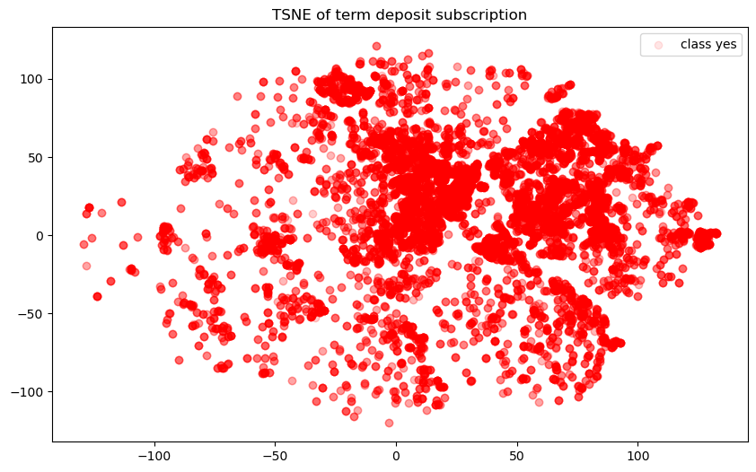

```python
plot_data(ros_df, only_subscriptions=True)
```

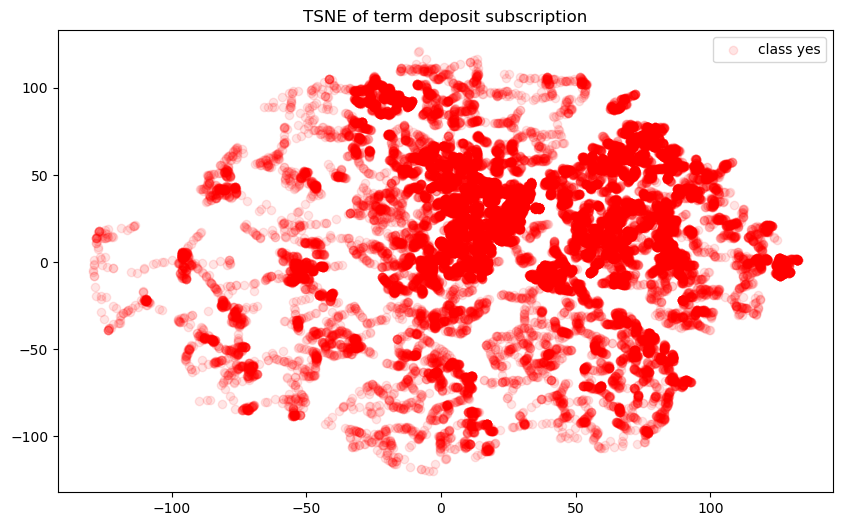

```python
plot_data(smote_df, only_subscriptions=True)
```

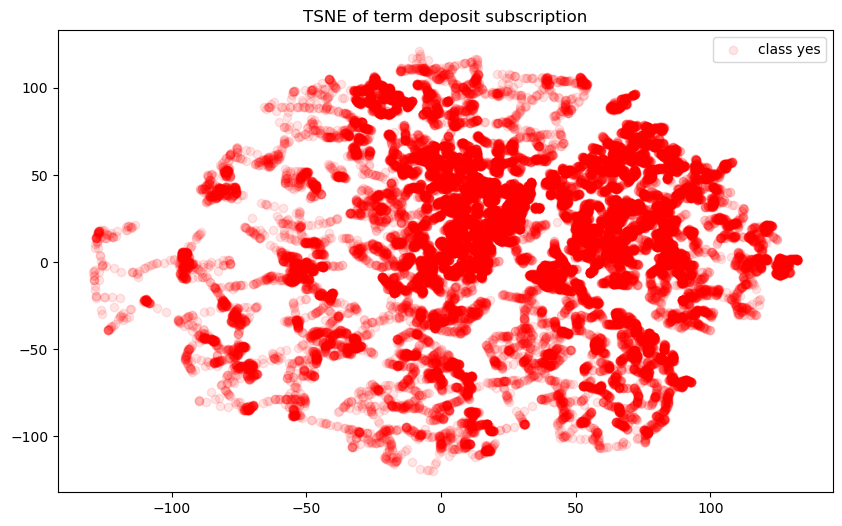

```python
plot_data(adasyn_df, only_subscriptions=True)
```

**Análisis:** teniendo en cuenta el número de muestras con contratación en cada conjunto, comentad las diferencias y similitudes en las imágenes del ejercicio anterior. Justificad la respuesta teniendo en cuenta el comportamiento de cada una de las técnicas utilizadas.

**Solución:** La principal diferencia entre la técnica "Random Oversampling" y, "SMOTE" y "ADASYN", es que las dos últimas generan **nuevos** datos sintéticos interpolando elementos de la clase minoritaria con sus vecinos más cercanos en el espacio de características, mientras que Random Oversampling simplemente copia muestras ya existentes. Este es el motivo por el que percibimos como unas "líneas" de puntos en las dos últimas técnicas.